# Jinlong Zhang's blog

2022-04-01

# 在本地运行awk版本的phylomatic-awk利用植物名录生成进化树

2022-03-31 12:00:00

# 在本地运行awk版本的phylomatic-awk利用植物名录生成进化树

Phylomatic网页版在2021年下线后，Cam Webb提供了phylomatic-awk (https://github.com/camwebb/phylomatic-awk)。可先下载zip包到本地，保存为phylomatic-awk-main.zip。

该软件是用awk语言写成的，在安装了awk解释器的计算机上就可以运行。本文以Windows10系统为例，介绍awk版本的phylomatic的运行。

要运行awk版本的phylomatic，当然要先安装awk的解释器。rtools和git两个软件，就都内置又awk的解释器，因此，只要系统装了rtools (https://cran.r-project.org/bin/windows/Rtools/)或者git (https://git-scm.com/), 同时将awk添加到电脑的启动路径（也就是将awk.exe添加到系统路径中，以便于从cmd调用），就可以在本地运行phylomatic了。

在Windows10中具体添加awk.exe到启动路径的方法是：

1. 找到gawk.exe的路径，如果安装了git，则路径一般为 `C:\Program Files\Git\usr\bin`， 如果安装了rtools，则路径一般为 `C:\rtools40\usr\bin`

[figure not shown]

图1

2. 在桌面找到“我的电脑”，点击鼠标右键，“属性”，点击“高级系统设置”>“环境变量”>“系统变量”>找到 “path”>，点击“编辑”

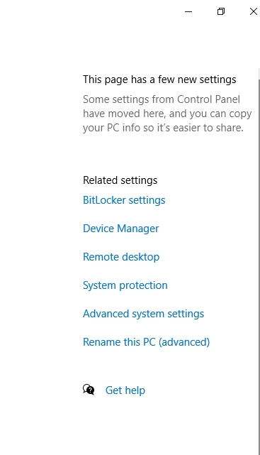

图2

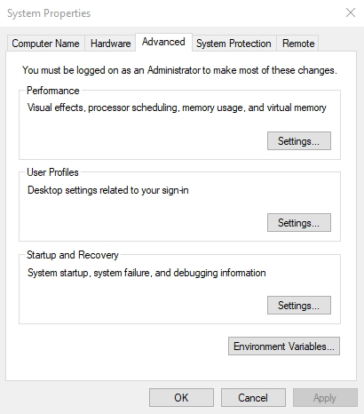

图3

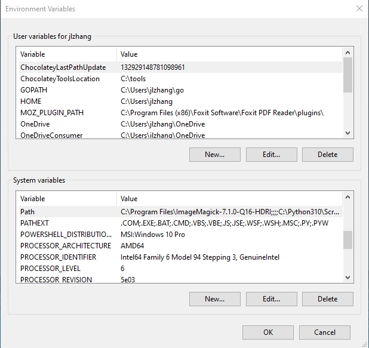

图4

3. 将`C:\Program Files\Git\usr\bin`添加到path中。

方法为：点击“新建”,在最底一行粘贴 `C:\Program Files\Git\usr\bin`

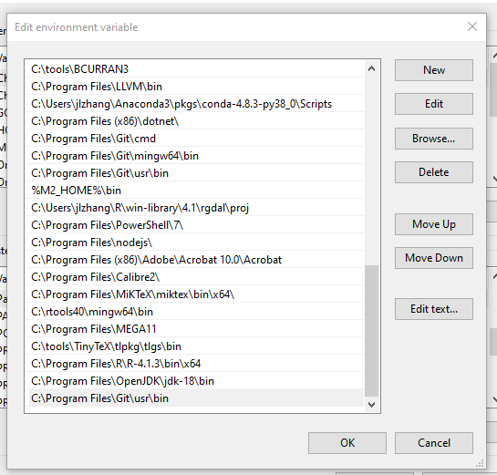

图5

4. 测试gawk.exe是否添加成功：

方法为： 回到桌面，右键点击鼠标，点击 git bash here。然后在新窗口中，输入`gawk`，若结果如图所示，则添加成功。

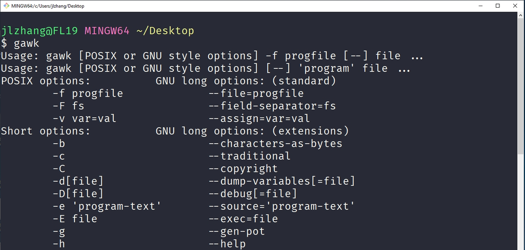

图6

5. 用7zip或者winrar解压缩 phylomatic-awk-main.zip
6. 打开 phylomatic-awk-main 文件夹，鼠标右键点击git bash here 以打开git命令行窗口

[figure not shown]

图7

7. 在命令行窗口输入或者粘贴以下命令：

```bash
gawk -f phylomatic --clean --newick data/zanne2014.new --taxa examples/taxa2
```

按回车。

命令解释如下： - `gawk`： gawk是调用gawk.exe可执行文件，也就是awk语言的解释器。 - `-f phylomatic` 表示要运行的awk脚本名为 phylomatic。 - `--clean` 表示要获得的进化树是 clean的，不要有内部不必要的节点。 - `--newick data/zanne2014.new`： 表示进化树骨架的文件为`data/zanne2014.new`。 - `--taxa examples/taxa2`： 表示科、属、种列表的位置为`examples/taxa2`

结果显示如下：

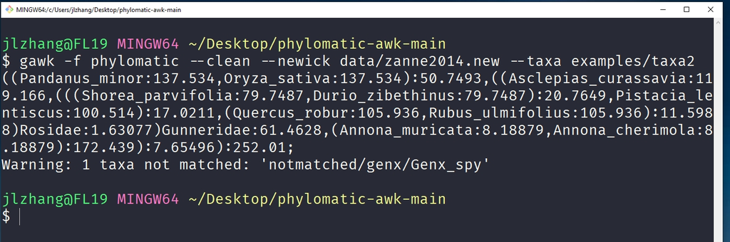

图8

图中，黄色的为路径，在鼠标右键打开就好。 以$符号开始的行为输入的命令。

要想将结果保存到文本文件中，需要输入如下命令：

```bash
gawk -f phylomatic --clean --newick data/zanne2014.new --taxa examples/taxa2>tree.txt
```

结果如下：

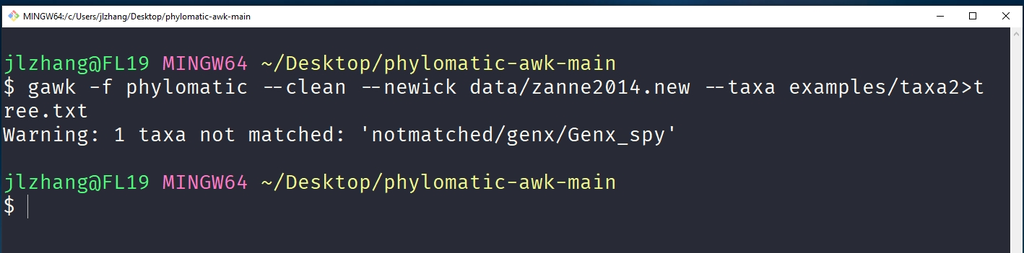

图9

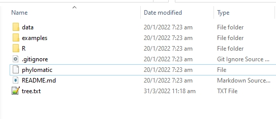

图10

[figure not shown]

图11

`>`符号的意思是将运行结果保存在`tree.txt`文件中。

上面就是用awk版本的phylomatic生成进化树的过程。

除了awk版本的phylomatic，要用科属种名录生成进化树，也可以用v.phylomaker R程序包，具体参见：

- https://github.com/jinyizju/V.PhyloMaker
- https://onlinelibrary.wiley.com/doi/full/10.1111/ecog.04434

用李代江博士的rtrees程序包也可以根据物种名录生成进化树： - https://github.com/daijiang/rtrees

2022-03-31

# 在本地运行awk版本的phylomatic-awk利用植物名录生成进化树

# 在本地运行awk版本的phylomatic-awk利用植物名录生成进化树

Phylomatic网页版在2021年下线后，Cam Webb提供了phylomatic-awk (https://github.com/camwebb/phylomatic-awk)。可先下载zip包到本地，保存为phylomatic-awk-main.zip。

该软件是用awk语言写成的，在安装了awk解释器的计算机上就可以运行。本文以Windows10系统为例，介绍awk版本的phylomatic的运行。

要运行awk版本的phylomatic，当然要先安装awk的解释器。rtools和git两个软件，就都内置又awk的解释器，因此，只要系统装了rtools (https://cran.r-project.org/bin/windows/Rtools/)或者git (https://git-scm.com/), 同时将awk添加到电脑的启动路径（也就是将awk.exe添加到系统路径中，以便于从cmd调用），就可以在本地运行phylomatic了。

在Windows10中具体添加awk.exe到启动路径的方法是：

1. 找到gawk.exe的路径，如果安装了git，则路径一般为 `C:\Program Files\Git\usr\bin`， 如果安装了rtools，则路径一般为 `C:\rtools40\usr\bin`

[figure not shown]

2. 在桌面找到“我的电脑”，点击鼠标右键，“属性”，点击“高级系统设置”>“环境变量”>“系统变量”>找到 “path”>，点击“编辑”

[figure not shown]

3. 将`C:\Program Files\Git\usr\bin`添加到path中。

方法为：点击“新建”,在最底一行粘贴 `C:\Program Files\Git\usr\bin`

[figure not shown]

4. 测试gawk.exe是否添加成功：

方法为： 回到桌面，右键点击鼠标，点击 git bash here。然后在新窗口中，输入`gawk`，若结果如图所示，则添加成功。

[figure not shown]

5. 用7zip或者winrar解压缩 phylomatic-awk-main.zip
6. 打开 phylomatic-awk-main 文件夹，鼠标右键点击git bash  
   here 以打开git命令行窗口

[figure not shown]

7. 在命令行窗口输入或者粘贴以下命令：

[output not shown]

```
gawk -f phylomatic --clean --newick data/zanne2014.new --taxa examples/taxa2
```

按回车。

命令解释如下：

- `gawk`： gawk是调用gawk.exe可执行文件，也就是awk语言的解释器。
- `-f phylomatic` 表示要运行的awk脚本名为 phylomatic。
- `--clean` 表示要获得的进化树是 clean的，不要有内部不必要的节点。
- `--newick data/zanne2014.new`： 表示进化树骨架的文件为`data/zanne2014.new`。
- `--taxa examples/taxa2`： 表示科、属、种列表的位置为`examples/taxa2`

结果显示如下：

[figure not shown]

图中，黄色的为路径，在鼠标右键打开就好。 以$符号开始的行为输入的命令。

要想将结果保存到文本文件中，需要输入如下命令：

[output not shown]

```
gawk -f phylomatic --clean --newick data/zanne2014.new --taxa examples/taxa2>tree.txt
```

结果如下：

[figure not shown]

`>`符号的意思是将运行结果保存在`tree.txt`文件中。

上面就是用awk版本的phylomatic生成进化树的过程。

除了awk版本的phylomatic，要用科属种名录生成进化树，也可以用v.phylomaker R程序包，具体参见：

- https://github.com/jinyizju/V.PhyloMaker
- https://onlinelibrary.wiley.com/doi/full/10.1111/ecog.04434

用李代江博士的rtrees程序包也可以根据物种名录生成进化树：

- https://github.com/daijiang/rtrees

2022-01-15

# 当下

下班后，我要去标本馆拷个文件，顺便找找《Memoirs of the Hong Kong Natural History Society(21号)》(1997)，里面有几篇文章介绍香港植物分布新记录。

说不定标本馆的书架上有呢？ 我心想。

将近六点，同事们都走了。天空也渐渐暗下来，黑夜的幕布悄悄落下。标本馆周围异常安静，只有远处的公路上汽车来来往往，车声传到耳畔。

这一天，又要结束了？！在去标本馆的路上，我心里忽然打了个寒颤，想着：“莫不是，自己的生命，又少了一天么？”

标本馆内的走廊幽暗而漫长，到了尽头，标本室也黑暗而阴沉。我开了灯，标本室就洒满了光明，钢铁制作的标本柜似乎一下子也变得温暖了。我拷了文件，在书架上找那本杂志。

书架上都是些很老的杂志和植物志，大部分都已几十年了，有些还是1950年以前的，纸页泛黄，字体是那种很古旧的有衬线字体，类似LaTeX里面加粗的Serif。如果你看过1950年以前的英文刊物，应该对那种字体并不陌生。

还有一些泛黄的手稿，都安静地躺在那里，仿佛熟睡的孩子。

大部分手稿都是本园植物学家Gloria Barretto（1916-2007）的。她去世后，手稿由家人捐给了植物园。Gloria和胡秀英教授是好朋友，二人曾一起发表过一些兰花新种。

手稿的英文整齐秀美，每一页都堪称艺术品。凝视着那流畅的字迹，我总有一种说不出来的欣喜和感动。我敬佩她细致入微的观察，敬佩她对美的追求，敬佩她一丝不苟地书写还有对材料系统地整理。也许，但凡有成就的人，都是极善于思考，又勤奋如一、孜孜以求的人。其实，从手稿和文字，就不难看出一个人的治学态度。展开手稿，我脑海中就浮现出一位极为认真的女植物学家在伏案书写的场景。

书架上还有几本几十年前的项目报告，也都装订得非常整齐。另有一本复印的植物采集史资料，封面上做了整齐的标注。再有就是Botanical Journal of the Linnean Society杂志，也都装订成册，全部躲在角落里……资料很多，但是我要找的那本不在。

古旧书籍和手稿十分珍贵，因为它们承载着历史，还有前辈们用一生的心血所留给世间的东西。这份心血要永远不被时光消磨才好。

时光流逝，我们长大、衰老，而那些书籍、手稿也跟我们一样，在一天天衰老，变得越来越脆弱，越来越害羞，然后沉默不语，归于沉寂。它们中的大部分，也许终其一生，只能在架上休眠，能否醒来，何时醒来，没有人知道。

我忽然又想到人本身：人的命运跟这些图书，真有几分相似呢! 等人年老了，发挥完了光和热，把世间的一切就看得越来越透彻，也就越来越沉默寡言，最后归于恬淡，归于自然。

我忽然又回想起多年以来逝去的亲人和朋友，忽然很神伤：世界上没有什么是永恒的，一切美好的人和事，都是出现在该出现的时间而已，都值得遇到的人心怀感激。

除了吉光片羽的回忆，我又努力回想那些亲人和朋友究竟给我留下什么：好像什么都没有……也许有，但是又似乎介于有和无之间……往日的时光，难以追寻，那时光里的人们，有些只留下了只言片语，而大部分，似乎什么也没有留下。也许这也就是苏东坡为什么说“人生到处知何似？应似飞鸿踏雪泥”吧。我努力回想过去时光里的一些人，发现那人已不见踪影，只能将这种怅然尘封在记忆里。

说到底，此时此刻，也将变成往日的时光，让未来的你，在某一天里怅然和叹息。那时候，你可能忽然心生一丝感激，感激那时的相逢。也许重逢有日，在未来的某一天，但是，一切都只能从当下开始。

2022年1月14日 初稿  
2022年1月15日 修改

香港大埔

2021-11-05

# 林村河

林村河是一条非常短的河流，发源于大帽山北坡，最远处发源于嘉道理农场的小溪，流经林村谷，大埔，最后注入吐露港。

林村河的上游有很多支流，最靠西侧的一支可能就在嘉道理农场。嘉道理农场的小溪在旱季几乎会完全干涸，只留下几个浅浅的小池塘，偶见能见到一些小鱼以及两栖动物，如香港瘰螈等。

雨季，溪水经常暴涨。大暴雨过后，几百米外都能听到隆隆的水声，此时溪水完全变了模样，再也不是平日温文尔雅的涓涓细流，而是脱缰的野马，不顾一切向下奔腾，然后随时会撞上桌子大小的磐石，水花四溅，发出巨响，而整个溪流变成一条白练，似雾，似雨，又似雪。溪流奔涌着，也带来一阵阵凉风，裹挟着细小的水花，沾到脸颊，睫毛上，头发上，还有衣服上。

溪边不能久留，一则担心溪水会暴涨，二则伫立良久，难免会全身湿透。

第二天清晨雨过天晴，溪流又完全没了脾气，虽然还没有变成涓涓细流，却也温柔起来，没有了那雷鸣般的怒吼声，潺潺的水声仿佛是在向谁倾诉，小溪变身往日的模样。小鱼在大石头围成的小池塘里嬉戏，小池塘清澈见底，底下是黄色的粗糙沙粒，可能是大自然特意为了鱼儿有地方休息和觅食铺就的。溪边树上的小鸟也婉转鸣叫，在金色的阳光里嬉戏。

小溪从嘉道理农场的sun garden cafe继续向北穿过林锦公路，然后遇到一座名叫大刀刃的小山，就转向东北，流向林村谷。转弯的地方正好是嘉道理农场的本土树木苗圃。有不少同事在这里工作。有几位同事每个星期去香港的郊野公园采集野生植物的种子，并在此清洗、播种、发芽、移栽、除草、捉虫、测量等。本土树木苗圃从来不用杀虫剂、除草剂等，这是因为，第一，此地属于林村河的上游，若有化学物质流入，则整个河流生态系统可能因此被破坏，毒物可能在食物链中不断富集，最终伤害到人和各种野生动物；第二，生于苗圃中的动物，如各种昆虫、“杂草”，本是自然的一部分，只要适度控制就好，不必将它们赶尽杀绝。

小溪经过嘉道理农场本土树木苗圃以后，就变得平缓起来，继续流向下游，滋养着一个个村庄。

在林村谷，这条河主要流经白牛石、水窝、麻布尾、大庵、坪朗、太阳车、新村、新塘、钟屋村、放马莆、社山等等。这些村落中居住的主要为客家人。据说村民的先祖主要是清朝中期解除海禁之后，由广东五华、梅州等地迁来。地势平坦的地方向来被居住在此地的广府人占据，所以客家人只能进山，或者在山脚下居住，并以耕田为生。

林村河的另一个支流是梧桐寨旁的溪流，也发源于大帽山北坡。沿此溪流而上，可至大帽山700m左右的高处，溪流上游可再分成几条支流。最西侧的一条接近嘉道理农场最高处的兄弟纪念亭。沿着这条溪流据说可以找到香港唯一一棵观光木，此树最早是由华南植物园的邢福武教授在1997-1998年在香港调查植物时发现的。根据标本采集记录，邢教授和嘉道理农场的吴世捷博士跑过香港很多偏远的地区，有不少有意思的发现。当然，他们的标本有些到现在还未鉴定。

梧桐寨最出名的，要算是瀑布群了。这里山高路险，分布着最少四个比较长的瀑布，由低到高，分别称为井底瀑、中瀑、主瀑和散发瀑。

游览梧桐寨瀑布，可先由林锦公路巴士站上梧桐寨村，从万德苑的行山径直上，一路从100m左右上到500m左右。虽然比较辛苦，但是无论是景色，还是做植物考察，此路还是非常值得一探。

梧桐寨山谷差不多为香港植物生物多样性最高的地方，沿途可见四、五百种植物，有不少较为稀有，有大片的蜘蛛抱蛋、大叶仙茅，马蓝等，还能见到蓝树、粗壮润楠、香港㭴木、野芭蕉、大柱霉草等等。近年来我和同事刘金刚、朱慧玲也沿着此路发现过若干种香港分布新记录，如雷公连、山黑豆、醉魂藤、竹叶榕等。

瀑布是消暑的好去处，虽盛夏时节，太阳炙烤，瀑布下面却仍十分凉爽。行山人士往往在瀑布下歇脚，拍照，吃东西以补充能量，更有甚者还有人身着比基尼在瀑布下的池塘中游泳(当然法律不允许)。

我曾带中科院生态环境中心李宗善博士到此瀑布游览，李博士见到这几个瀑布，赞叹道，“没想到香港还有这么壮观的瀑布，其实庐山三叠泉也不过如此”。

梧桐寨溪流向下，流经寨乪(qi1)，与嘉道理农场的一只汇合，就组成了林村河，水流变得平缓。

据说，这一段原本生长着很多金钱龟。当然，现在肯定没有了。一只金钱龟，能卖到十几万港币，没有人能淡定，根本会放过它们。过去，金钱龟主要是用来做龟苓膏，近年来又说能有防癌抗癌的功效，还能大补元气，所以被当成宝贝。金钱龟的药效是真是假不知道，但有人抓是真的，这也导致其种群迅速减少，成为动物保护的一个突出问题。时至今日，如果沿着溪流而上，有时候仍然能够见到抓金钱龟的笼子，不法分子连最后一只都不想放过。

到达新村以后，林村河已经完全用水泥硬化了，最初目的可能是为了减少河水对土地的侵蚀。林村河现在也不用再发挥什么灌溉的功能，因为林村谷里面几乎没什么农田了，只有一些桃园，农历新年前卖“合时桃花”，有几个菜畦，村民在此种一些“有机蔬菜”，供自己食用。

经过较寮下村之后，林村河向南转。那里有一个泵站，称为“大埔头抽水站”，泵站下是一个橡胶滚水坝。干旱季节，滚水坝就充满了水，在上面形成一个小池塘，以免整条河流断流、干涸。附近常有一些鹭鸶捕鱼。

再往下流经梅树坑，该村风水林中有一棵很大的人面子树，胸径有两米以上，相比已经有一两百年以上。

再下游，林村河就流经大埔墟，成为太和以及大埔墟的分界。河上有太和桥、广福桥、宝乡桥等，行人络绎不绝。其中，只有宝乡桥能通车，这座桥联系着大埔墟与大埔中心。

河岸的树木上常有大量白鹭驻足，它们白天到吐露港捕鱼，天色暗下来的时候就回到树上休息。河边还偶尔有人钓鱼去喂鹭鸶，争食的主要是一些夜鹭，而白鹭因为胆子比较小，见到人就飞走了。

河流到达广福村附近，距离大海就只有咫尺之遥，咸度增加，硬化过的河岸开始出现一些蚝，越靠近吐露港就越多。

吐露港是香港的内海，据说这里在古代盛产珍珠。采珠人腰系着绳子，憋着气，潜入深达八米到十米的水中，捞出珍珠蚌。这样做当然十分危险，但是有买卖，就有伤害，古今中外概莫能外。在古代，采珠不仅仅伤害的是珍珠蚌，更是普通人。没有任何保护装备，一潜入深水，可以说是命悬一线。

吐露港的海水，随着涨潮，每日两次倒灌入林村河，河流下游变成咸淡水交界的地带，因此，这里生活着多重咸淡水交界的鱼类，常见的如“乌头”，也就是鲻，还有一种称为金鼓的小鱼，入侵的金山鲫，也就是罗非鱼，更是不计其数。

在靠近广福村的地段，林村河与另一条小河，也就是从大帽山东侧打铁刃发源，流经碗窑、荔枝坑的大埔河汇合，然后一起汇入吐露港。

在知道林村和以前，我从未想过一条河流从诞生到汇入海洋可以如此之短。河流的最终归宿是大海，无论长短。有的做到了，有的没有到达目的地就蒸发殆尽。在自然里，水在无尽的循环之中：从海面蒸腾，在空中凝结成云，然后再冷凝成雨，落回大地，再变成涓涓细流，变成江河湖泊，最后汇入大海，无穷无尽，无始无终。

这是个循环，所以，真的很难说是大海滋润着河流，还是河流滋润着大海。不过有一点可以明确，正是因为有了这种生生不息的循环，才有了世间万物，而人，原本只是自然中的一分子，要时时刻刻记得爱护它。

2021年11月5日

2021-09-13

# 最初的小学时光

因为疫情，两年以来一直不能回家，最近对家乡的思念越来越深了，总是想着父母，想着十四户村，想着郝各庄，尤其是怀念在村里上小学时的几年时光。

我高中以前一直在村里的学校念书，成绩还凑合。

那时候学校条件很简陋，老师都是本村或附近几个村的，没什么高学历或职称，但对孩子们都非常好，真心实意的那种好。说实话那时候不记得有教师节，也从未想过给老师送什么礼物，每天就知道傻淘，过年过节甚至一句祝福的话也都没说过，想想似乎有些过分了。

一年级时，教室是村里旧罐头厂的厂房，外面是蓝砖，顶上是蓝瓦，但墙身里面是土坯，不太坚固，且早已年久失修。课桌椅更是破破烂烂，桌面上刻了各种字，坑坑洼洼，有些还被钻了洞，有些裂缝很大，铅笔都能漏下去，老式课桌没有桌斗，书包只能挂在侧面。

学校前面有个小操场，被菜园包围，一下雨全是泥巴，洼处常积水十天半月，没有靴子很难到教室。冬春季小操场尘土飞扬，学生在操场跑一圈回来好像在土里打了个滚。暑假时，操场总是长满杂草，返校日其中一个任务就是除草。

一年级的教室距离操场比较远，又有前排房子阻挡，课间只能在教室前的空地玩儿些游戏。

学校门口朝东，门外是个鱼塘。旧罐头厂的碎罐头瓶、瓶盖子，还有附近几户的生活垃圾全都倒到这里。那时候孩子们也不知道什么是脏，男孩子都跑到垃圾堆上找有聚光功能的玻璃瓶底。中间厚，四周薄的玻璃瓶底才有聚光功能，谁要是找到了这种，简直就找到宝贝。找块石头，把瓶底四周多余的玻璃磕掉，弄得尽量圆一些，就大功告成了。这玻璃瓶底有如同放大镜，主要用来聚焦太阳光，一般先照自己手背，看看聚焦能力强不强，如果强，就用照蚂蚁，照酸菜柳(酸模叶蓼)叶子。要是谁的瓶子底聚光能力超强，能把作业本照糊了，发出一阵蓝烟，谁的嘴角就肯定挂着得意的笑，能骄傲半晌。

还有一种游戏就是钓“骆驼”：先揪一根细三棱草(某种莎草)的花葶，用下面最嫩的黄色部分去钓骆驼。“骆驼”其实是一种生在土里的小虫，比米粒大些，棕黄色，背上有一个凸起，因此得名骆驼。“骆驼”总是躲在一个火柴粗细的小圆洞里，一般被踏平的操场上，暑假过后的乱草丛边就能找到很多。骆驼洞都是直上直下的，有五到十厘米深。将三棱草的花葶轻轻伸进去，不能用力，以免骆驼受伤。过一两分钟，如果花葶轻轻动了，就是骆驼开始咬了，这时候要将花葶提起来，不能太快，也不能太慢，骆驼才能出来，很考验耐心和技巧。谁钓上骆驼来了，仿佛也能骄傲一阵子。

那时候，除了一些扔布球、丢手绢、跳格子、欻老么核，玩“鸡毛蒜皮”、来方宝、摔破锅，就没啥别的游戏了。男孩子最喜欢的弹球（玻璃球），学校自然是不让带的。

教室外立着根铁杆子，大概有七、八米高，周围拉着三道钢丝绳，顶上是村里的大喇叭，有电线通到不远处的村委会。杆子上面焊着一些倒三角形的脚蹬子，可以很容易爬上去，下课了有些学生就去爬，幸运的是没出什么事情。村里一喊广播，几米以外的教室里倒也听得清楚。

有一天晚上，阴云密布，电闪雷鸣，好像就要下大雨了，不过最终只是刮了几阵风，下了阵小雨，刚把地皮打湿。第二天早上，天放晴了，我高高兴兴背着书包到学校，一看吓了一跳：教室塌了。只见房梁斜插到教室里面，屋顶的砖头瓦块全都压到了地面上，桌椅板凳也都砸坏了，黑板直接晒着太阳。还好是在夜里出的事，如果是白天，老师和学生们都在上课，出什么事就不一定了。

过了一段时间，我们搬进了附近的另一间“教室”。又过了几个月，全部班级搬到了河南边的新小学，距离旧学校两百米。

新学校的教室都是红砖房，有前后两排，后排好像是十来间，前排是两层，六间，两层房中间是个过道，通向前面的操场。

教室里都是新换的桌椅板凳，桌面深绿色，桌身黄色，新课桌椅都散发着浓浓的油漆味。教室墙壁雪白，贴着一些红纸、绿纸，上面写着“业精于勤荒于嬉，行成于思毁于随”，“书山有路勤为径，学海无涯苦作舟”等，那时候认不好毛笔字，好像过了很久才知道上面写的是什么。教室红砖铺地，地面十分干爽，特别是打扫卫生时，灰尘总是让人喘不过气来，再也不是旧教室的泥土地面了。教室门窗都镶着玻璃，室内也是宽敞明亮。我们就在这新学校里，上到了四年级。

那时候具体学了什么，已经完全没印象了。只记得有一段时间，好像是二年级，我数学不太好。那次期中考试，有几道数学填空题，题目给出了一些竖式，数字中夹杂着一些小方框，学生要填合适的数字到方框里面。那题目到现在我好像还不太会做，是真正的童年阴影。

那次考试，我在全班十六个同学中考了倒数第六，回到家被父亲一顿训斥，那是我第一次看父亲那么生气。当时，我发誓努力学习，成绩有所提高。不过到后来还是不愿意做作业，甚至有一个学期还把书丢了。

那学期好像还发了一本黄色书皮的语文课外阅读，里面有一首《明日歌》，让人记忆犹新：“明日复明日，明日何其多。我生待明日，万事成蹉跎”。是啊，凡事不能一直推到明天，尽量“今日事，今日毕”。

一到四年级教我的，是本村的李老师，她除了耐心向我这个小淘气传授知识，更重要的，其实是教会我怎么诚实做人。一年级时，还是在旧教室，我的自动铅笔笔头的小铁管好像被偷了，没法写字，于是我在课件又偷了同学自动铅笔笔头上的小铁管，同学发现后立即告诉了老师。老师问是谁弄的，我只能低着头、红着脸站起来承认错误。李老师让我将同学的铅笔弄好，并向人家认真道歉，从此我知道了不能拿别人东西，做了错事要勇于承担，要诚实对待自己和周围的人。

最后一次见李老师是二十年前了，当时我高中毕业，在村南头偶然遇到。李老师见我长成了大人，十分激动，不住地说，“长大了，跟小时候不一样了……”。我当时也十分激动，说以后有机会会常去看她。只是，之后好像没过多久，李老师就因病不在了。

三十年前的事，仿佛只是一场梦。而今天的事，到了明天，也将成为一场梦。当人和物都还在，也许人能够仿佛回到到梦一般的过去，而更多时候，往事只能成为一种念想，时时提醒我们珍惜今天的人和事，珍惜现在的一切。

2021年9月11日，9月13日修改

于香港大埔

2021-07-25

# 种豆记

有一天，孩子从幼儿园带回一件小手工：一个彩绘鸡蛋壳，里面放了一块棉花，有几棵柔弱的绿豆芽生在这块棉花上。

在幼儿园，老师叮嘱孩子们说，要记得给豆芽浇水，这样，豆芽就会变成豆苗，慢慢长大，结出新的豆子。

孩子记住了老师的话，生怕豆苗渴了，跟我说一定要记得给豆苗浇水。

我说：“豆芽现在可以在鸡蛋壳里，但是它长大以后就需要土壤，还需要阳光，这样长能出豆子。新的豆子种下来，就能再发芽、长大……”

过了几天，这几棵豆芽果然长了叶子。我买了花盆和花土，将豆苗小心翼翼地栽到了盆里，豆苗就在盆里生长了。

豆苗继续长大，有两三片叶子了，我就想，要不给它们加点儿肥料吧，于是买了一小瓶花肥：一个小玻璃瓶里装着棕色的小颗粒，说明书上说可用于各种花卉。

我害怕肥料加多了会伤到豆苗，于是只加了六、七粒，浇足水。过了三四天，豆苗一下子都蔫了，叶子慢慢干枯、脱落……原来，这豆苗太娇嫩，一点儿肥都不能施。

只有一棵豆苗坚持了下来，长了四五片叶子，有半米多高。

一天，我忽然发现它开了一朵黄绿色的花，只有指甲那么大，花朵低垂，毫不起眼，也没什么香味。

我跟孩子说：“快来看，豆子开花了，开花了就可能结豆角，就能长豆子了。”

孩子赶紧过来看，开心得跳了起来：“爸爸，我好希望它能长出豆子啊！”

我说：“爸爸也希望！”

花开了两三天就谢了。豆苗继续长叶，我隔一天为它浇一次水。又过了几天，我不经意间发现，一条细小的豆荚长出来了。它，每天都在长大，每天都伸长一点点。阳光从窗口斜射进来，隐约能看到青绿色的豆荚里正在慢慢长大的豆子。

豆苗还在长高，在最上面的几片叶子下又新开了几朵黄绿色的花。

天有不测风云：豆子在长得太细太高，很容易倒下，于是我把它绑在铝窗边上，没注意到豆荚也贴在了铝窗上。

一天下班回家，我忽然发现豆荚贴在铝窗上，而豆荚中间变得很软，有些发暗，原来，是铝窗被太阳晒热，烫到了成长中的豆荚。唉，我是多么希望这豆荚健康长大，自然成熟、裂开，散出最成熟，最饱满的种子……现在这种情况只能想办法补救了。为了防止豆子再被烫伤，我赶紧在墙边加了一些纸板，将豆苗固定在纸板边上。

可能豆苗的茎也被烫伤，它的叶子一片片干枯了，之前见到的花也一朵一朵落了，浇水也无济于事。唯一的豆荚也变干变黑，我想，真是可惜了，豆子也肯定还没成熟，应该不能种了。

又过了两个月，我早已把豆子的事情忘了。

一次去超市，买的蒜里面有几瓣蒜发芽了，我跟孩子说：“要不我们把发芽的蒜种下来吧?”

孩子点点头，说：“好，我很想让蒜长大成蒜苗。”

为了种蒜苗，我清理了窗台上早已干枯的豆苗，那豆荚又黑又小，没有裂开。剥开豆荚，里面有七粒特别细小的绿豆，都还没有饱满，大小只相当于正常绿豆的一半还不到。

我问孩子：“要不我们试试这豆子能不能发芽？”

孩子说：“那就试试吧”

我说：“这次要是能发芽，一定要把它们种在大花盆里，让它们在深厚的土壤中生长，这样它们就能长大、开花，长出新豆子了。”

孩子说：“还不能施肥”

我说：“那肯定的”

为了测试这几颗豆子能不能发芽，我在马克杯里面放了一小块布，打湿后将豆子放在布上，再用边缘盖好。

第二天中午，我打开杯子里的布，惊讶的发现七颗豆子中的六颗已经吸饱水分。吸足水分的豆子，每一颗都圆滚滚的，绿色的皮，从中间裂开，一个白色的嫩芽从裂缝中探出来，开始往布里面钻。

没想到绿豆这么快就能发芽! 我赶紧拿来事先准备好的一个大花盆，添上花土，按了按，淋了一些水，挖了一个小坑，将豆子轻轻转移到坑里面，再盖了薄薄的一层土。与此同时，我将那几瓣发芽的蒜也种好了，种在了原来种豆苗的花盆里。

第三天早上，我发现一颗豆子可能没盖太好，“豆芽”正横着生长，先端向下，好像正吃力地往土里钻。见此情形，我赶紧从别处弄了点儿土盖了盖。

又过了一天，豆苗你争我抢地从土里钻出来了，顶上的“豆瓣”向两端分开，颜色嫩黄，夹在中间的绿色叶子也正要展开。豆苗虽小，却让花盆里充满了绿色的力量。同时种的蒜苗，嫩绿的芽也从土里钻出来了。

不知道为什么，小苗的长大，总是充满了各种坎坷：从鸡蛋壳里萌发，到随时可能被扔掉，再幸运地移栽到花盆，长叶后被肥料伤害，再被铝窗烫伤，结出孱弱的种子。

我忽然想对那小苗说，不管怎样，无论遇到什么，都不要放弃，有绿色，就有希望。没有人知道，那微小的种子孕育着怎样的力量，会结出怎样丰硕的果实。

2021年7月26日

2021-07-19

# 植物学和生态学的一些R语言学习资源

## 软件

- R：https://www.r-project.org
- Rstudio： https://www.rstudio.com
- VScode： https://code.visualstudio.com
- git - 简易指南 https://rogerdudler.github.io/git-guide/index.zh.html
- tinytex: https://yihui.org/tinytex/
- Miktex: https://miktex.org

## 程序包

- The learnr package *Interactive Tutorials for R* https://rstudio.github.io/learnr/
- Yu Guangchuang *ggtree* https://guangchuangyu.github.io/software/ggtree/
- 谢益辉等 *Rmarkdown* https://rmarkdown.rstudio.com/
- 谢益辉等 *blogdown* https://bookdown.org/yihui/blogdown/
- 谢益辉等 *pagedown* https://github.com/rstudio/pagedown
- sf 程序包 https://r-spatial.github.io/sf/
- CRAN Task Views: https://cran.r-project.org/web/views/ 程序包分类列表
- awesome-R https://github.com/qinwf/awesome-R
- Roxana Noelia Villafañe *Learning R - Resources* https://github.com/data-datum/learning_R
- Karthik Ram, Scott Chamberlain, and Carl Boettiger et. al. *ropensci* https://ropensci.org/packages/

## 图书

- 李东风 *R 语言教程* https://www.math.pku.edu.cn/teachers/lidf/docs/Rbook/html/_Rbook/Rbook.pdf
- 王敏杰 *数据科学中的R语言* ： https://bookdown.org/wangminjie/R4DS/ 课程录像 https://www.bilibili.com/video/BV1VE411N765/
- Jenny Bryan *Data wrangling, exploration, and analysis with R* https://stat545.com/
- Winston Chang *R Graphics Cookbook, 2nd edition* https://r-graphics.org/ 主要介绍ggplot2的用法
- Daniel Borcard, François Gillet and Pierre Legendre *Numerical Ecology with R, second edition* http://adn.biol.umontreal.ca/~numericalecology/numecolR/ 数量生态学在R中的实现，赖江山博士翻译过中文版。
- Emmanuel Paradis *Analysis of Phylogenetics and Evolution with R* https://www.springer.com/gp/book/9781461417422 进化分析必读
- Emmanuel Paradis *Population Genomics with R 1st Edition* https://www.amazon.com/Population-Genomics-R-Emmanuel-Paradis/dp/1138608181 群体基因组学必读
- Robin Lovelace, Jakub Nowosad and Jannes Muenchow *Geocomputation with R* https://geocompr.robinlovelace.net/ 空间分析和地图绘制
- Roger D. Peng (2020) *R programming for data sciences* (https://bookdown.org/rdpeng/rprogdatascience/)
- Wickham, H *R for data science* (https://r4ds.had.co.nz/)
- Claus O. Wilke *Fundamentals of Data Visualization* (https://clauswilke.com/dataviz/)
- Jack Taylor *Data Skills for Reproducible Science* https://psyteachr.github.io/msc-data-skills/
- Hadley Wickham *The tidyverse style guide* https://style.tidyverse.org/
- Danielle Navarro *Learning statistics with R* https://github.com/djnavarro/rbook https://tidylsr.djnavarro.net/
- Edzer Pebesma, Roger Bivand *Spatial Data Science with applications in R* https://keen-swartz-3146c4.netlify.app/ 空间分析经典
- Robert Tibshirani, Jerome Friedman, *The Elements of Statistical Learning: Data Mining, Inference, and Prediction. Second Edition* https://web.stanford.edu/~hastie/ElemStatLearn/ 机器学习经典
- James, G., Witten, D., Hastie, T., & Tibshirani, R. (2013). An introduction to statistical learning. New York: springer. (https://www.statlearning.com/) 机器学习最好的入门图书之一
- Guisan, A., Thuiller, W., & Zimmermann, N. E. (2017). [Habitat suitability and distribution models: with applications in R. Cambridge University Press.](https://www.cambridge.org/gb/academic/subjects/life-sciences/quantitative-biology-biostatistics-and-mathematical-modellin/habitat-suitability-and-distribution-models-applications-r) code: https://github.com/vdicolab/hsdm R语言物种分布模型入门
- Gotelli, N. J., & Ellison, A. M. (2004). A primer of ecological statistics (Vol. 1). Sunderland: Sinauer Associates. 生态学数据分析经典入门
- Michael Whitlock and Dolph Schluter *The Analysis of Biological Data* https://whitlockschluter3e.zoology.ubc.ca/ UBC的生物学数据分析
- Altuna Akalin *Computational Genomics with R* https://compgenomr.github.io/book/ 计算基因组学
- 张敬信 *R语言编程–基于tidyverse* (https://github.com/zhjx19/introR)
- 邓飞 *R语言进阶笔记* (https://dengfei2013.gitee.io/r-language-advanced/)
- Xie Yihui *bookdown: Authoring Books and Technical Documents with R Markdown* https://bookdown.org/yihui/bookdown/ 用Rmarkdown写书
- Xie Yihui, Christophe Dervieux, Emily Riederer *R Markdown Cookbook* https://bookdown.org/yihui/rmarkdown-cookbook/ Rmarkdown秘籍
- Xie Yihui, Amber Thomas, Alison Presmanes Hill *blogdown: Creating Websites with R Markdown* https://bookdown.org/yihui/blogdown/ 用Rmarkdown写博客

## 课程

- University of Massachusetts Boston Bio607 *生物统计课程 Biol 607: Intro to Computational Data Analysis for Biology* (https://biol607.github.io/)
- Geography 503: GEO Spatial Data Science https://github.com/AdamWilsonLabEDU/GEO511 空间分析
- Walter Jetz, Erica Stuber, Cory Merow, Scott Rinnan, Brett Jesmer, Gabriel Reygondeau, Ruth Oliver (2019) EEB 713, Spring 2019: Concepts and methods in global biodiversity change research in the age of big data https://cmerow.github.io/YaleBGCCourses/ https://github.com/cmerow/RDataScience 耶鲁大学的大数据与生态学课程
- François Michonneau and Auriel Fournier *Data Analysis and Visualization in R for Ecologists* https://datacarpentry.org/R-ecology-lesson/ 为广泛采用的DataCarpentry的课程材料
- David Zelený *Analysis of community ecology data in R* https://www.davidzeleny.net/anadat-r/doku.php/en:start 群落数据分析
- Jenny Bryan, the STAT 545 TAs, Jim Hester *Happy Git and GitHub for the useR* https://happygitwithr.com/ 学习使用git和github
- *R for Reproducible Scientific Analysis* http://swcarpentry.github.io/r-novice-gapminder/
- *DATA SCIENCE FOR ECOLOGISTS AND ENVIRONMENTAL SCIENTISTS* (https://ourcodingclub.github.io/course.html)

## 操作指南

- Karl Broman *R package primer a minimal tutorial* https://kbroman.org/pkg_primer/ 编写R程序包
- Robert J. Hijmans and Jane Elith *Species distribution modeling* https://rspatial.org/raster/sdm/index.html dismo、raster、terra等程序包的作者Robert Hijmans写的空间分析材料

## 快速参考

- R Studio Cheatsheets: https://www.rstudio.com/resources/cheatsheets/

## 网站

- 统计之都： https://cosx.org/
- Hadley Wickham的个人网站，介绍tidyverse: http://hadley.nz/
- 谢益辉的个人网站: https://yihui.org/
- Karl Broman的个人网站：https://kbroman.org/talks.html
- Robin Lovelace的个人网站： https://www.robinlovelace.net/
- Adam B. Smith 的个人网站 https://github.com/adamlilith

## 视频

22. *R语言编程* https://www.bilibili.com/video/BV1D7411T77Z?from=search&seid=1630947937465437556
23. YOUTUBE R语言编程合集: https://pan.baidu.com/s/1_wyj1sTeb7wp4cWFwk6Vzw 提取码：6pfj

## 其他

- 英国生态学会 Guides to Better Science指南系列 https://www.britishecologicalsociety.org/publications/guides-to/

This work is licensed under a [Creative Commons Attribution-NonCommercial-NoDerivatives 4.0 International License](http://creativecommons.org/licenses/by-nc-nd/4.0/).

2021-05-15

# 生态学研究生要清楚的三件事：从《生态学家必读的100篇论文》说起

2017年11月，澳大利亚两位生态学家F. Courchamp 和C. Bradshaw咨询了几本主要生态学期刊的编辑，经过提名和投票，整理出了推荐次数最多的论文，并发表了题为“100 articles every ecologist should read”的论文。

这篇文章一上线就引起了轩然大波，有人认为所选论文太老而且偏重于群落生态学，也有人认为所选论文的作者，在性别、年龄、种族等方面存在非常严重的偏差，很多并不能算生态学的“必读”文献。PLOS对此还专门展开讨论，随后在博客中贴出了讨论结果。还有人还专门给编辑部写信，质疑所选论文的客观程度，论文作者不得不逐条反驳。

为什么一篇论文会引起这么大的争议呢？可能论文中有些细节确实没有交代清楚，但是上述提到的各种偏差其实是真实存在的，而这在一定程度上与生态学的起源和发展过程有关。

现代生态学诞生于欧洲，后来在欧美逐渐发展壮大，成为一门“显学”。确实像有人指出的，这100篇论文的作者绝大部分为欧美的“白人男性”，女科学家以及世界其他地区研究者的论文基本没有入选，中国生态学家的名字，更是根本就没有出现。

为什么这100篇推荐的作者里面没有中国人呢？仔细观察，就会发现，这些文献确实都比较老，大部分已经发表了三、四十年以上，而国人真正开始认真思考和研究现代生态学问题，不过是近二三十年的事，在此之前，国人大多不太理解生态学是什么，也很少有机会参与生态学理论的提出与发展。

生态学是理论性和实践性都非常强的学科，由于要深入研究生物与环境之间的关系以及生物与生物之间的关系，一般认为是建立在数学、生物学和地理学以及土壤、气候等学科之上，需要大量理论和知识的积累，也需要很好的传承才能蓬勃发展，而这些都时间。不得不承认，由于积累不足，国内总体的生态学理论水平距离欧美顶尖科学家的水平还有一定差距。国人在生态学研究中起跑时就慢了，所以经典的英文文献里很少出现国人的名字也很正常。

近些年，特别是最近十年，国内的生态学迎来快速发展，中国生态学家也在不同领域奋起直追。也许在不久的将来，中国生态学家也会提出一些原创性的理论，能够和欧美的生态学家站在同一个研究梯队，甚至能在某些领域做到引领。

要做到这些，就需要国内学者和有志于此的研究生们以极大的热情和诚意投身学术，少些急功近利，多些务实求真。其中很重要的一点，就是按照自己的兴趣和社会需求潜心研究，相信我们也将做得很出色并最终为人类文明的进步做出自己的贡献。

大多数有志于科学研究的人，其实都是为了理想和信念做事。想要做好，一定要有长久的兴趣以及不畏困难的恒心、决心与信心，拥有敢于怀疑的精神，关键时刻还要不屈不挠，跟各种困难做斗争。

最近，科学网博客上一位老师说，“最好的学术研究都源于对事物的精深理解”，此话不虚。对事物理解透彻了，自然而然就会有新发现，形成自己的观点，在前人的基础上有所创造，有所发明。但上面提到的“理解”有一个前提，就是从理论和方法上全方位“理解”自己感兴趣问题的本质，知道其研究进展和前人的得失，明白现有研究的不足之处，这样才能知道努力的方向，研究才会有前瞻性。要做到这些着实不易，其中很多与研究生教育密切相关。

求学路上，障碍有很多。结合现状，我觉得至少有三点是研究生们需要清楚的，只有认清了这些障碍，才能采取相应对策突破障碍。那么究竟有哪些主要障碍呢？

第一，语言。目前，全世界的专家在学术领域都用英文交流，好的论文绝大多数以英文写成，而国内的英文教育情况大家也知道。因为很多学生外语还不够好，难以在一定时间内阅读足够的文献，要真正读懂、读透往往有困难，这就必须要多花时间，精读文献，特别是导师要求阅读的文献。如果阅读文献都还存在困难，就更别提融会贯通，别提体会到作者思想的精妙之处了。如果没能真正理解研究，要进一步提出自己的观点和理论就更困难了。

第二，批判性思考。生态学是理论性非常强的学科，除了要大量阅读文献资料之外，还要勇于质疑已有的理论和方法，这样才能提出新见解、新方法。不过，国内的基础教育长期以来主要是教学生背诵各种公式、定理，这种方式教出来的学生做题、考试没有问题，虽然基础也比较扎实，但是由于在学习过程中很多人丧失了独立思考和质疑的能力，等到了研究生阶段，遇到问题往往感觉很迷茫。

科研中，批判性思考是科学家成长的关键，发现前人的不足，对现有知识体系的质疑与批判，对方法的创新等，都是学科发展的重要推动力。如果在教育过程中从小就去限制了学生去自由探索，剥夺了他们的好奇心，以后再想让他们自由思考就难了。如果缺乏好奇心，对事物的本质就不会感兴趣，就提不出更深层次的问题。如果缺乏批判性的思考，就不会质疑现有的理论，更难以提出自己的见解和理论。这种情况下，研究也只能人云亦云，哪儿还可能做得出色？越是考试厉害的学生，越要留意这一点。

第三，研究方法。科学研究需要用数据去支撑，用实验结果去验证理论是否正确。不仅如此，由于生态学是极为重视数量方法和统计的学科，生态学家和研究人员其实每天要和各种数字、模型、图表、统计方法打交道。问题来了，生态学研究所需的原理和方法，其实大部分学生都缺乏足够的训练。本科生阶段课程设置也许还可以，但是到了研究生阶段，往往课程设置就跟不上了。

目前，生态学数据分析要用到的平台主要是R和Python，而且实际的研究中需要不少高级统计内容，如广义线性混合模型、最大熵、极大似然估计、贝叶斯统计等，还要处理空间数据如温度、降水等气候因子，或者要处理较大规模的数据。要掌握这些统计分析的高级内容，需要掌握大量计算机和编程的知识和技能，同时还要掌握近年发展起来的数据清洁、可视化的工具软件，制定合理的工作流程等等。除了之外，学术期刊还经常要作者提供原始数据和以及相应代码，以便让研究经得起检验。

由于上述知识和技能在一般的《生物统计学》课程中大多没有涵盖，很多人为了提高自己的技能不得不参加各种培训班。但这些培训班往往质量参差不齐而且价格不菲。如果导师愿意资助学生接受相关培训还好，如果导师不同意，学生可能会相当沮丧。更痛苦的是，若没有掌握上述提到的技能，就很难看懂最新的文献究竟在说什么。研究生要将自己的研究发表在主流SCI期刊，一般情况下都要用到这些方法，因此一定要花费大量的时间和精力去学习。由于不同人的基础和悟性不同，学习过程可能既快乐又痛苦。

研究方法的免费开源学习资料，包括文档、代码和练习数据，英语世界比较多，很多是专业人士热心贡献给学生学习的。相比之下，国内掌握相关技术的专业人员要么忙于自己的论文，无暇顾及其他，也有的只在课题组做一些内部培训，没有时间在互联网上传授这些技能。也有人在熟练掌握这些科研技能后第一时间忙着办培训班，相关的讲义、代码等都只能给培训班的学员，严禁外传，更不会在网络上分享。

俗话说，“教会徒弟，饿死师傅”，也许正是因为上述原因，中文世界里生态学与进化相关的数据分析方法指南才少得可怜。虽然大家都知道给学生提供足够的培训机会，让他们得到训练，对于学生科研能力的养成至关重要，但究竟谁能做，怎么做，最终只能看个人的精力与情怀了。

这里只列出本人觉察到的三个障碍，是否每个人都会遇到这三个障碍，是否还有别的更大的障碍就只能由读者自己去总结和归纳了。

最后，本人觉得这100篇“必读”文献是否真的要读其实并不重要，很多也可能根本没必要读。而真正重要的，是那些生态学家怎样在某一领域做到了“从0到1”的突破，生态学又是怎样从他们的观点出发继续向纵深发展的。论文的作者究竟是怎么让他们的论文如此重要，直到几十年、上百年之后的今天，我们还要继续学习和借鉴的？当然，这100篇论文的作者，他们的国籍、肤色、性别的偏差确实是值得警醒的问题，对此，不同学者已经做了深入探讨，这里就不赘述了。

说到第三个障碍，这里不得不提一下本人参与的一项公益计划。在BioONE—生物多样性与生态安全大数据平台（[https://www.bio-one.org.cn/）](https://www.bio-one.org.cn/%EF%BC%89) 负责人马克平研究员的鼓励和支持下，若干位对数据分析有一定经验的专业人士正计划录制一批生物多样性数据分析视频，希望对生态学的研究生和青年科研人员有帮助。相关的讲义以及全部代码等都将免费下载和使用。对网友在学习过程中的问题，主讲人也将尽量在BioONE平台上解答。如果你在生物多样性数据分析中有什么感兴趣的内容或者好主意，希望这些视频能讲解，或者想成为视频的主讲人，欢迎email联系本人。

众人拾柴火焰高，大家齐心协力，中国生态学的学术氛围就会越来越好，研究成果越来越多，影响也将越来越深远。

## 进一步阅读：

- Courchamp, F., & Bradshaw, C. J. (2018).100 articles every ecologist should read. Nature ecology & evolution, 2(2),395-401.
- 生态学100篇必读文章招来了大麻烦[http://blog.sciencenet.cn/blog-470284-1096656.html余国志的博客](http://blog.sciencenet.cn/blog-470284-1096656.html%E4%BD%99%E5%9B%BD%E5%BF%97%E7%9A%84%E5%8D%9A%E5%AE%A2)
- 为什么生态学100篇必读文章有严重偏差[https://theplosblog.plos.org/2017/12/525600-minutes-365-papers-and-100-articles-every-ecologist-should-read/PLOS博客](https://theplosblog.plos.org/2017/12/525600-minutes-365-papers-and-100-articles-every-ecologist-should-read/PLOS%E5%8D%9A%E5%AE%A2)
- NEE|生态学家必读的100篇论文中文翻译http://blog.sciencenet.cn/blog-313491-1270274.html 杨预展的博客
- 生态学博士生“必读”的100篇文献http://blog.sciencenet.cn/blog-260340-1086053.html 高建国的博客
- 科研中最重要的任务是理解，创新会在理解的过程中自然而然地产生http://blog.sciencenet.cn/blog-3234816-1285367.html 钟定胜的博客
- 100论文的作者男女比例失调https://www.nature.com/articles/s41559-017-0444-8
- 100论文作者的偏差问题https://www.nature.com/articles/s41559-017-0441-y
- 生态学期刊编辑不能代表生态学家的总体https://www.nature.com/articles/s41559-017-0443-9

2021-05-13

# 生活的答案

我小时候，父亲在县化肥厂工作，是厂里的仓库保管，后来因为勤奋好学，不断进修，成为一名材料会计。

化肥厂大约是1975年，由河北工学院（今河北工业大学）设计，解放军某部施工建设的，父亲从筹建化肥厂时就在那里工作了。

当时，厂里只能生产碳酸氢铵。碳酸氢铵又称“气儿肥”，容易烧苗，虽然如此，但当时所有人都知道，化肥是种庄稼必不可少的，所以都争相购买，一时间化肥供不应求。化肥厂开业之后几年，村里不少人买化肥，都要托关系、走后门。父亲是其中一个“后门”，而且为人厚道，十分热心，虽然并没有收过什么好处，但是混了个好人缘，在村里更是风光无限。

那时候，父亲早上六点半左右就从家里出发，骑着辆二八加重的飞鸽自行车。车的后轮挂着一个小发电机，车子骑起来就发出“呜呜呜呜”的声音，给车前面的磨电灯供电，用来赶夜路的时候照亮。家里距离县城有二十多里路，要一个多小时“车程”才能从县城回到家，父亲下班到家，很多时候天都已经黑了。

父亲的车把上，总挂着一个黑色人造革皮包。晚上七点多，听到车子一响，我总是第一时间从屋里冲出去，目的是看看父亲的皮包里面有没有好玩儿的、好吃的。

我上小学二、三年级的时候，县化肥厂倒闭了，国有资产被悉数贱卖，肥了一大批人，但是苦了工人。父亲也失业了，那时候不能叫失业，只是说下岗。他是非农业户口，没有土地。

那一年，我不知道他承受了怎样的打击。屋漏偏逢连夜雨，奶奶忽然瘫痪在床，大姑也病了，家里的积蓄本来就不多，现在只能先紧着治病。

当时，父亲只有三十多岁，但好像一下子老了一些。为了养家，他带着母亲一起卖小杂货、糖葫芦、炒螺蛳，想尽各种方法挣钱。

小杂货是小本生意。一般是用铁丝编个笼子，里面摆上自动铅笔、橡皮、玻璃弹球、气球、玩具枪、画片、贴纸、泡泡糖，还有自己包装的五香瓜子，到小学门口等学生下课或者放学来买。

为了吸引学生，让他们掏出零花钱，父亲还发明了“轱辘”球的游戏。

“轱辘”球类似抽奖，赌的是运气。将一块木头削成立方体，再削掉八个角，就有点像球形。将“木球”涂上绿油漆，每个面再写上一定的数字。轱辘球时，人站在画好的一根线后面，将球向前滚动，哪个数字朝上，就给几倍的奖励。

“轱辘球”大受欢迎，想必确实增加了不少营业额。除此之外，为了促销，有一段时间，父亲还跟学生玩儿抓玻璃球的游戏，学生抓对了相同颜色的球就会有奖。

冬天，山里红（山楂）、黑枣（君迁子）、山药（薯蓣）、酸梨（安梨）都下来了，父亲便走街串巷卖糖葫芦。每到晚上，我也跟着一起准备第二天要蘸的糖葫芦。父母起得很早，生火、熬糖、蘸、甩糖翅儿，工序一样都不能少。蘸糖葫芦很危险，一不小心，粘稠滚烫的糖就会把手烫伤。糖葫芦蘸好后就可以插到糖葫芦杆子上，推出去走街串巷去卖。

有时候要先打听哪里有红白喜事，如果有，就早早过去。红白喜事人多，要选个好位子，糖葫芦就能多卖很多。有时候父亲自己去卖货，有时候是父母一起去。

父亲习惯了坐办公室，习惯了保管仓库，他对仓库里的东西如数家珍，各种阀门、各种电机、各种螺丝钉、电线、各种工具，甚至它们的规格、型号至今都记得一清二楚。上次回家探望父母，父亲还跟我提过。

他在厂里上班的时候，肯定不曾想过自己有朝一日还要去卖杂货，要在刺骨的寒风中卖糖葫芦，自食其力，挣钱养家。

冬天卖糖葫芦、卖杂货，夏天就是去铲“螺子”。螺蛳，宝坻称为螺子。将螺蛳放在清水中拔两天，让其吐净脏东西，再将螺丝外壳的藻类用力搓掉。然后在大锅中加少许清水，加茴香、大料、白芷并加盐翻炒，等到螺蛳的盖掉下来，就炒好了。用水桶盛好，放入车后的笼筐子里，就可以沿街叫卖了。

一般是母亲去卖炒螺蛳，而父亲去方圆几十里的河沟里铲螺蛳。

铲螺蛳非常辛苦。父亲买了一个汽车内胎，一般称为“皮轱辘”，事先充好气，驮在自行车后，见到一个小河沟就要去看看有没有螺蛳。

先将“皮轱辘”放入水中，中间放上大盆，再穿上衩子，防止身上被水浸湿，手里抓住螺蛳铲，就下水了。

螺蛳铲是一种特制的工具，前面是一块铁板，后面是网兜，铲到的螺蛳就落在网兜里。农村的河沟，深一脚，浅一脚，没有人知道水下究竟有什么，只能自己判断哪里危险，哪里能去，哪里不能去。

盛夏时节，有时候，一天能铲两编织袋螺蛳。无论多累，无论出过多少汗，如果铲到了螺蛳，父亲都会绽放开心的笑容。有了螺蛳，家里的开支就有了着落。不过，有时候河沟的水太深，而铲子的长度不够，就只能望洋兴叹。

父亲用坏了两把螺蛳铲，还有就是为后来的一把换了根杆子。

家里的猪圈前面，不知道什么时候生了一棵小刺槐，本来嫌碍事砍掉了。不曾想又从根部萌发了两根小苗，长到七八米高。父亲选了其中的一根，做了螺蛳铲的杆。另外一根，在十几年后的2013年，已长成一个人抱不过来的大树，有二十多米高，成了鸟类的乐园，上百只灰喜鹊每天在树上喳喳乱叫。2014年，家里盖新房，这棵大树碍事，有人出价五十元要买，父亲没同意。再后来，还是将树卖掉了。

从高中生，到工人，再到下岗失业；从风光无限，到走街串巷兜售瓜子、糖葫芦，铲螺蛳……也许这就是人生。人生没有标准答案，好好生活，用坚强和勇敢去生活，就是标准答案。

2021-05-07

# 新种、新分布与植物爱好者的“发现权”

新分类单元的发表和修订，对于厘清类群的系统发育关系、进化过程等十分重要，对于物种的保护与合理开发利用有极为重要的意义。

近年来，由于自然保护意识的提升，不少人对植物有了浓厚的兴趣，甚至达到痴迷的程度，他们走遍山野去拍摄植物，并将照片上传到各大论坛、网站，分享和鉴定，值得肯定和赞扬。随着能力的提升，一些植物爱好者还发表了新种，例如兔儿风属、苦苣苔科、秋海棠属等类群都有这样的例子。

不过，更多情况下，新种是由分类学家发表的。分类学家在论坛或者图库浏览照片时，发现照片中的是新种，于是安排人采集标本，解剖、绘图，系统查阅标本，命名，撰写描述，编制检索表，弄清楚和近缘种的区别，有时还要建立分子系统树，弄清楚分类单元之间演化的关系，然后才成功发表新种。发表新种，一般情况下都需要经过专门的训练才能做到，而且费时费力，超出了一般爱好者的能力范围。

虽然新种多是由分类学家发表的，但新种发现过程中，如果爱好者有着至关重要的作用，那么他们的贡献在论文中就一定要好好体现。一般来说，体现爱好者贡献的方式有三种：(1)加为论文共同作者或者种的共同命名人；(2)在正文中介绍发现的过程；(3)如果爱好者对论文的写作和新种的发现没有直接贡献，但是在这一过程中提供了很多帮助，则应在致谢中表示感谢。

如何体现爱好者的贡献，是每个分类学家在发表由爱好者发现的新种之前都要认真思考的，为了了解他们的诉求，需要与爱好者好好沟通。双方误会可大可小，如果不认真对待，说不定就会惹来麻烦，闹出不快，为将来的合作蒙上阴影。

最近就听说有爱好者要求自己发现的新种以产地命名，想为自己所在的城市增光添彩，但是后来发现新种的论文中自己的贡献完全没有体现，想到自己在论文发表前为植物学家采集标本带路，而最后发现论文中根本没有提过自己的名字，就不由得十分恼火。

由于觉得贡献没有很好体现，爱好者心中颇为不满。碰巧这位分类学家不善处理人际关系。爱好者多次联络分类学家后，对方始终没有重视。爱好者遂将此事转告给好友，为打抱不平，有些人在网络上发帖，对分类学家展开言语攻击，称涉事的分类学家“道德败坏”，呼吁广大爱好者终止与其合作，全面抵制等等，弄得双方都极为不快。经过多次协商，最后，分类学家发表论文的勘误，回应爱好者们的诉求，此事才算解决。

这种情况，很可能是一开始双方沟通不善，特别是分类学家在撰写论文时没有考虑周全。当然，有些分类学家只知道埋头做事，不善于跟人打交道，导致情况失控，因此对事件有一定的责任。而作为爱好者一方，因为命名的问题，对分类学家穷追猛打，最后两败俱伤，想必也是得不偿失。当然，另一个角度来说，算是成功炒作了一把。

除了新种的命名权、发现权以外，还有一些更让人匪夷所思的事：前段时间，同事发了一篇香港植物分布新记录的论文，里面报道了十几个新分布。

在论文写作时，我们其实特别想着要体现爱好者的贡献，尽量将他们列为论文的共同作者，如果不愿意列入，则在致谢中列出。

文章发表后，有网友给同事留言，坚称是自己发现了某个新分布记录，说自己原本将新分布记录种的照片在若干年前就贴到某网络论坛上，而我们的论文没有体现他的贡献，新分布的发现过程他显然应该“有份”，除此之外，这名网友还对作者们的人格不停贬损、攻击，声称从论坛里找到物种新分布，这样轻轻松松就“获得新分布的发现权”，这样写论文发表真是“功夫了得”，必然“损害学术”，而所在机构更是不能“纵容这种做法”。这些攻击、谩骂让人不得不佩服这位爱好者的逻辑和脑洞。

其实，我们报道的植物新分布，几乎是我们在野外调查中独立发现的，并未参考过论坛中的信息，论坛和网站中当然更查不到“新分布”发现的地点。自然论坛里面都是素不相识的网友，按照论坛的规定，用户可以问植物是什么，但是不能透露植物分布的地点，以免种群被破坏。即使我们想在论坛里问陌生网友拍摄地点，人家也不会告诉你。不知道分布地点，就没有办法采集标本，没有标本，何谈写论文报道新分布？难道能凭借网站上一张照片信口开河？

因为发表一篇植物物种分布新记录的论文遭受无端指责和攻击，这种事情还真是闻所未闻。爱好者若承认物种在论文中列出，就有了物种在某地的“发现权”，则应该在发现后第一时间撰写论文，这样，他所坚持的“发现权”就不会“旁落”到别人手中。那名爱好者的态度似乎也表明，他很清楚报道物种在一个地方有分布是需要写出论文的。而他可能不清楚另一点，那就是写新分布的论文是需要引证标本的，而且需要发表在有正式刊号的刊物上。如果这一点都不明白，声称早在多年以前就发现了新分布，就只是无稽之谈罢了。

当然，不得不承认，植物论坛、图库、博客、个人网站都有很大的参考价值，但是由于其内容庞杂，大部分未经过评审，没有经过严格的出版程序，所以并不属于出版物，都只能属于灰色文献，可信度比较低。同时，这些文献大多难以找到稳定的永久网址，查找和引用是大问题。对于大部分植物学家来说，已经正式发表的科学论文看都看不完，哪有闲暇关注这些灰色文献？哪儿有时间通过若干论坛联系未曾谋面的网友呢？谁能保证联系他们的时候不吃闭门羹，甚至受到另一种形式的人身攻击呢？

类似的攻击和指责，显然是严重偏离事实，对于一心扑在物种发现和保护的植物学工作者来说显然是很不公道的。

我们常说为人要大度，要宽容，无论爱好者还是科学家其实都是如此。当受到诽谤，植物学家们当然非常不开心。忽然想起《史记·屈原列传》里说：“信而见疑，忠而被谤，能无怨乎?” 植物学家们要是都遇到这样的爱好者，能不生气吗？